# Project Python Foundations: FoodHub Data Analysis

### Objective

The food aggregator company, FoodHub, has stored the data of the different orders made by the registered customers in their online portal. They want to analyze the data to get a fair idea about the demand of different restaurants which will help them in enhancing their customer experience. Suppose you are hired as a Data Scientist in this company and the Data Science team has shared some of the key questions that need to be answered. Perform the data analysis to find answers to these questions that will help the company to improve the business.

## **Business Analysis and Recommendations**

This section summarizes the key findings from the data analysis and provides recommendations for improving FoodHub's business operations and customer experience.

### **1. Understanding Customer Behavior and Market Trends: Insights for Strategic Growth**

Based on the analysis of the dataset, several patterns and trends in customer behavior and the market have been identified. These insights can inform strategic decisions for continued growth.

1. American, Japanese, Italian, and Chinese cuisines dominate orders, collectively representing almost 80% of total volume and highlighting key areas for targeted marketing and restaurant acquisition strategies.
2. 128 out of 178 restaurants (72%) receive repeat orders.
3. Orders are significantly higher on weekends, accounting for 71% of total order volume, indicating a strong weekend demand and potential for targeted weekend promotions and resource allocation.
4. 50% of orders are under 15 dollar and 75% are under 23 dollar suggests that a significant portion of customer base tends to place orders within a lower to moderate price range. This indicates that many customers are likely budget-conscious.
5. Consistent food preparation times (ranging 20-35 mins, mean ~27 mins) support reliable delivery estimates.

### **2. Identifying and Addressing Business Challenges: Opportunities for Optimisation**

FoodHub can improve its service and address existing challenges to optimize operations and enhance customer satisfaction.

1. To drive significant business growth, FoodHub must prioritize strategies aimed at converting the 65.33% of customers who currently order only once into repeat patrons, potentially by addressing factors contributing to unrated orders and enhancing the initial customer experience.
2. 50 out of 178 restaurants (28%) have received only a single order.This highlights an opportunity to address factors hindering their recurring business through the platform.
3. A large proportion of orders are not rated, but when ratings are given, they are predominantly positive (4 or 5 stars). This highlights the opportunity to encourage more customers to rate their orders, potentially through implementing customer incentive programs.
4. Delivery times appear to be longer on weekdays compared to weekends, which may contribute to lower order volumes during the week and presents an opportunity for FoodHub to improve delivery efficiency.

### Importing the required libraries

```python
# Install the libraries
!pip install numpy==1.25.2 pandas==1.5.3 matplotlib==3.7.1 seaborn==0.13.1 -q --user
```

**Note**: *After running the above cell, kindly restart the notebook kernel and run all cells sequentially from the start again.*

```python
# Import libraries for data manipulation
import numpy as np
import pandas as pd

# Import libraries for data visualization
import matplotlib.pyplot as plt
import seaborn as sns
```

### Understanding the structure of the data

```python
# Mount your google drive
from google.colab import drive
drive.mount('/content/drive')
```

```python
# Read the data
df = pd.read_csv('/content/drive/MyDrive/Colab Notebooks/foodhub_order.csv') ## Fill the blank to read the data
```

```python
# Set display width for pandas DataFrames
pd.set_option('display.width', 400)
```

```python
# Examine the first 5 rows
df.head()
```

|  | order_id | customer_id | restaurant_name | cuisine_type | cost_of_the_order | day_of_the_week | rating | food_preparation_time | delivery_time |
| --- | --- | --- | --- | --- | --- | --- | --- | --- | --- |
| 0 | 1477147 | 337525 | Hangawi | Korean | 30.75 | Weekend | Not given | 25 | 20 |
| 1 | 1477685 | 358141 | Blue Ribbon Sushi Izakaya | Japanese | 12.08 | Weekend | Not given | 25 | 23 |
| 2 | 1477070 | 66393 | Cafe Habana | Mexican | 12.23 | Weekday | 5 | 23 | 28 |
| 3 | 1477334 | 106968 | Blue Ribbon Fried Chicken | American | 29.20 | Weekend | 3 | 25 | 15 |
| 4 | 1478249 | 76942 | Dirty Bird to Go | American | 11.59 | Weekday | 4 | 25 | 24 |

```python
# Examine last 5 rows
df.tail()
```

|  | order_id | customer_id | restaurant_name | cuisine_type | cost_of_the_order | day_of_the_week | rating | food_preparation_time | delivery_time |
| --- | --- | --- | --- | --- | --- | --- | --- | --- | --- |
| 1893 | 1476701 | 292602 | Chipotle Mexican Grill $1.99 Delivery | Mexican | 22.31 | Weekend | 5 | 31 | 17 |
| 1894 | 1477421 | 397537 | The Smile | American | 12.18 | Weekend | 5 | 31 | 19 |
| 1895 | 1477819 | 35309 | Blue Ribbon Sushi | Japanese | 25.22 | Weekday | Not given | 31 | 24 |
| 1896 | 1477513 | 64151 | Jack's Wife Freda | Mediterranean | 12.18 | Weekday | 5 | 23 | 31 |
| 1897 | 1478056 | 120353 | Blue Ribbon Sushi | Japanese | 19.45 | Weekend | Not given | 28 | 24 |

Observation: The 'rating' column contains 'Not given' values.

### **Question 1:** How many rows and columns are present in the data? [0.5 mark]

```python
# Examine the shape of the dataset
df.shape
```

```
(1898, 9)
```

### **Answer 1:** The dataset has 1898 rows and 9 columns.

### **Question 2:** What are the datatypes of the different columns in the dataset? [0.5 mark]

```python
df.info()
```

```
<class 'pandas.core.frame.DataFrame'>
RangeIndex: 1898 entries, 0 to 1897
Data columns (total 9 columns):
 #   Column                 Non-Null Count  Dtype
---  ------                 --------------  -----
 0   order_id               1898 non-null   int64
 1   customer_id            1898 non-null   int64
 2   restaurant_name        1898 non-null   object
 3   cuisine_type           1898 non-null   object
 4   cost_of_the_order      1898 non-null   float64
 5   day_of_the_week        1898 non-null   object
 6   rating                 1898 non-null   object
 7   food_preparation_time  1898 non-null   int64
 8   delivery_time          1898 non-null   int64
dtypes: float64(1), int64(4), object(4)
memory usage: 133.6+ KB
```

### **Answer 2:** The columns in this dataset have float, int and object datatype.

### **Question 3:** Are there any missing values in the data? If yes, treat them using an appropriate method. [1 Mark]

```python
# Check for missing values in the data
df.isnull().sum()
```

|  | 0 |
| --- | --- |
| order_id | 0 |
| customer_id | 0 |
| restaurant_name | 0 |
| cuisine_type | 0 |
| cost_of_the_order | 0 |
| day_of_the_week | 0 |
| rating | 0 |
| food_preparation_time | 0 |
| delivery_time | 0 |

**dtype:** int64

### **Answer 3:** There any no missing values in the data.

### **Question 4:** Check the statistical summary of the data. What is the minimum, average, and maximum time it takes for food to be prepared once an order is placed? [2 marks]

```python
# Get the summary statistics of the numerical data
df.describe().T
```

|  | count | mean | std | min | 25% | 50% | 75% | max |
| --- | --- | --- | --- | --- | --- | --- | --- | --- |
| order_id | 1898.0 | 1.477496e+06 | 548.049724 | 1476547.00 | 1477021.25 | 1477495.50 | 1.477970e+06 | 1478444.00 |
| customer_id | 1898.0 | 1.711685e+05 | 113698.139743 | 1311.00 | 77787.75 | 128600.00 | 2.705250e+05 | 405334.00 |
| cost_of_the_order | 1898.0 | 1.649885e+01 | 7.483812 | 4.47 | 12.08 | 14.14 | 2.229750e+01 | 35.41 |
| food_preparation_time | 1898.0 | 2.737197e+01 | 4.632481 | 20.00 | 23.00 | 27.00 | 3.100000e+01 | 35.00 |
| delivery_time | 1898.0 | 2.416175e+01 | 4.972637 | 15.00 | 20.00 | 25.00 | 2.800000e+01 | 33.00 |

### **Answer 4:** The minimum food preparation time is 20 minutes, the mean is approximately 27 minutes, and the maximum is 35 minutes.

### **Question 5:** How many orders are not rated? [1 mark]

```python
df['rating'].value_counts()
```

|  | rating |
| --- | --- |
| Not given | 736 |
| 5 | 588 |
| 4 | 386 |
| 3 | 188 |

**dtype:** int64

### **Answer 5:** 736 orders out of 1898 are not rated.

```python
# check for duplicates
df.duplicated().sum()
```

```
0
```

### Exploratory Data Analysis (EDA)

### **Question 6:** Explore all the variables and provide observations on their distributions. (Generally, histograms, boxplots, countplots, etc. are used for univariate exploration.) [9 marks]

#### Order ID

```python
# Check unique order ID
print(df['order_id'].nunique())
```

```
1898
```

```python
# Check for duplicates
print(df.duplicated().sum())
```

```
0
```

There are no duplicate orders in the dataset.

#### Customer ID

```python
# check nunique of 'customer_id'
print(f"There are {df['customer_id'].nunique()} unique customers. Their id's are = {df['customer_id'].unique()}")

# Calculate the number of repeat orders by returning customers
repeat_orders = df.shape[0] - df['customer_id'].nunique()

# Calculate the total number of orders
total_orders = df.shape[0]

print(f"Repeat orders: {repeat_orders}")

# Calculate the percentage of repeat orders
percentage_repeat_orders = (repeat_orders / total_orders) * 100
print(f"Percentage of repeat orders: {percentage_repeat_orders:.2f}%")
```

```
There are 1200 unique customers. Their id's are = [337525 358141  66393 ...  97838 292602 397537]
Repeat orders: 698
Percentage of repeat orders: 36.78%
```

```python
# Get the count of orders for each customer
customer_order_counts = df['customer_id'].value_counts()

# Get the number of customers who have repurchased (placed more than one order)
customers_who_repurchased = (customer_order_counts > 1).sum()
print(f"Number of customers who repurchased: {customers_who_repurchased}")

# Get the total number of unique customers
total_unique_customers = df['customer_id'].nunique()

# Calculate the customer repurchase rate
customer_repurchase_rate = (customers_who_repurchased / total_unique_customers) * 100

print(f"Customer repurchase rate: {customer_repurchase_rate:.2f}%")
```

```
Number of customers who repurchased: 416
Customer repurchase rate: 34.67%
```

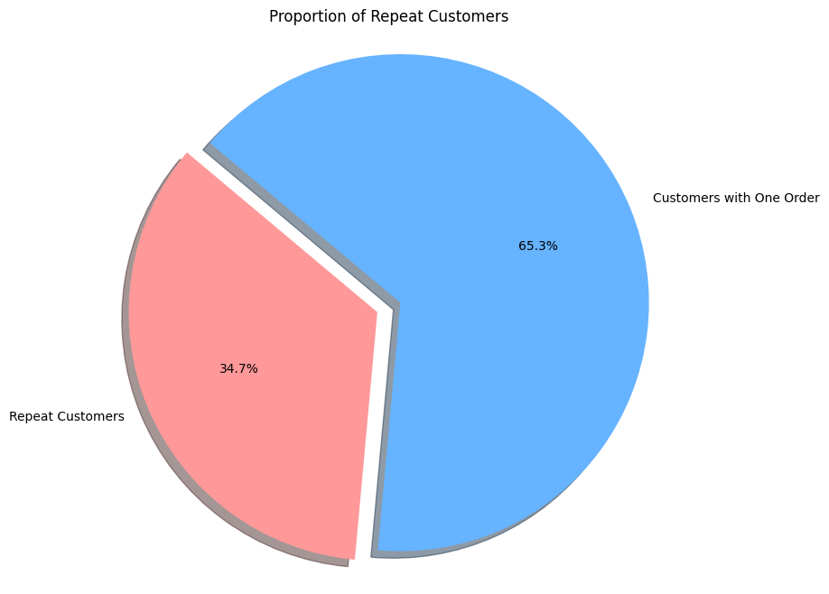

```python
# Calculate the number of orders per customer
customer_order_counts = df['customer_id'].value_counts()

# Get the number of customers who have repurchased (placed more than one order)
customers_who_repurchased = (customer_order_counts > 1).sum()

# Get the number of customers who have placed only one order
customers_with_one_order = (customer_order_counts == 1).sum()

# Data for the pie chart
labels = ['Repeat Customers', 'Customers with One Order']
sizes = [customers_who_repurchased, customers_with_one_order]
colors = ['#ff9999', '#66b3ff']
explode = (0.1, 0)

# Create the pie chart
plt.figure(figsize=(8, 8))
plt.pie(sizes, explode=explode, labels=labels, colors=colors,
        autopct='%1.1f%%', shadow=True, startangle=140)

# Add a title
plt.title('Proportion of Repeat Customers')

# Equal aspect ratio ensures that pie is drawn as a circle.
plt.axis('equal')

# Show the plot
plt.show()
```

**Investigate why customers who ordered only once might not have returned. Analyze the distribution of ratings, cuisine types, and day of the week for one time orders.**

```python
# 1. Identify customers who have ordered only once
customer_order_counts = df['customer_id'].value_counts()
one_time_customer_ids = customer_order_counts[customer_order_counts == 1].index

# Filter the DataFrame to include only orders from these one-time customers
df_one_time = df[df['customer_id'].isin(one_time_customer_ids)].copy()
```

```
Rating distribution for one-time customers:
Not given    297
5            246
4            166
3             75
Name: rating, dtype: int64

Percentage of rating distribution for one-time customers:
Not given    37.882653
5            31.377551
4            21.173469
3             9.566327
Name: rating, dtype: float64
```

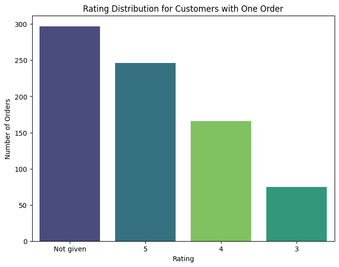

```python
# 2. Analyze the distribution of ratings for one-time customers
print("\nRating distribution for one-time customers:")
print(df_one_time['rating'].value_counts())
print("\nPercentage of rating distribution for one-time customers:")
print(df_one_time['rating'].value_counts(normalize=True) * 100)

# Visualize the rating distribution
plt.figure(figsize=(8, 6))
sns.countplot(data=df_one_time, x='rating', order=df_one_time['rating'].value_counts().index, palette='viridis', hue = 'rating', legend = False)
plt.title('Rating Distribution for Customers with One Order')
plt.xlabel('Rating')
plt.ylabel('Number of Orders')
plt.show()
```

```
Cuisine type distribution for one-time customers:
American          260
Japanese          161
Italian           137
Chinese            97
Mexican            39
Indian             27
Mediterranean      20
Middle Eastern     17
Thai                8
Southern            8
French              3
Korean              3
Spanish             3
Vietnamese          1
Name: cuisine_type, dtype: int64

Percentage of cuisine type distribution for one-time customers:
American          33.163265
Japanese          20.535714
Italian           17.474490
Chinese           12.372449
Mexican            4.974490
Indian             3.443878
Mediterranean      2.551020
Middle Eastern     2.168367
Thai               1.020408
Southern           1.020408
French             0.382653
Korean             0.382653
Spanish            0.382653
Vietnamese         0.127551
Name: cuisine_type, dtype: float64
```

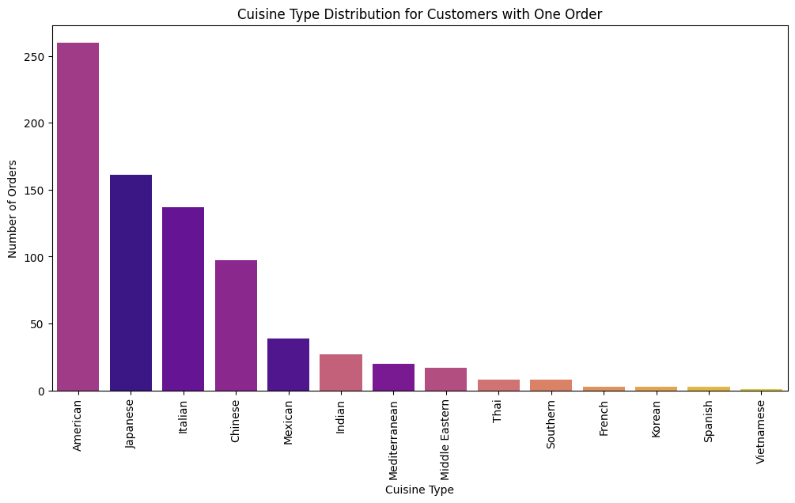

```python
# 3. Analyze the relationship with the cuisine type for one-time customers
print("\nCuisine type distribution for one-time customers:")
print(df_one_time['cuisine_type'].value_counts())
print("\nPercentage of cuisine type distribution for one-time customers:")
print(df_one_time['cuisine_type'].value_counts(normalize=True) * 100)

# Visualize the cuisine type distribution
plt.figure(figsize=(12, 6))
sns.countplot(data=df_one_time, x='cuisine_type', order=df_one_time['cuisine_type'].value_counts().index, palette='plasma', hue = 'cuisine_type', legend = False)
plt.title('Cuisine Type Distribution for Customers with One Order')
plt.xlabel('Cuisine Type')
plt.ylabel('Number of Orders')
plt.xticks(rotation=90)
plt.show()
```

```
Day of the week distribution for one-time customers:
Weekend    542
Weekday    242
Name: day_of_the_week, dtype: int64

Percentage of day of the week distribution for one-time customers:
Weekend    69.132653
Weekday    30.867347
Name: day_of_the_week, dtype: float64
```

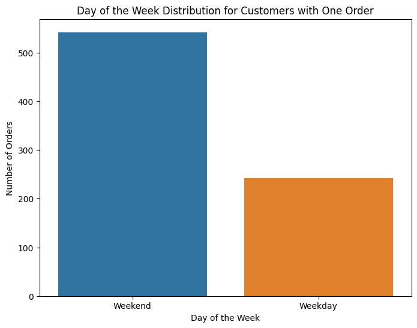

```python
# 4. Analyze the relationship with the day of the week for one-time customers
print("\nDay of the week distribution for one-time customers:")
print(df_one_time['day_of_the_week'].value_counts())
print("\nPercentage of day of the week distribution for one-time customers:")
print(df_one_time['day_of_the_week'].value_counts(normalize=True) * 100)

# Visualize the day of the week distribution
plt.figure(figsize=(8, 6))
sns.countplot(data=df_one_time, x='day_of_the_week', order=df_one_time['day_of_the_week'].value_counts().index, palette='tab10', hue = 'day_of_the_week', legend = False)
plt.title('Day of the Week Distribution for Customers with One Order')
plt.xlabel('Day of the Week')
plt.ylabel('Number of Orders')
plt.show()
```

Observation -

- Analysis of 1898 orders indicates they were placed by 1200 unique customers.
- Repeat orders are observed, accounting for 698 instances, which constitutes 36.78% of the total orders.
- Among the 1200 unique customers, only 34.67% have placed more than one order.
- **This suggests that a majority, 65.33%, have not returned for a second order.**
- **An opportunity exists for business improvement by implementing strategies to encourage repeat patronage from these non-returning customers.**
- The high percentage of "Not given" ratings among one-time customers is a strong observation. It suggests that for a substantial number of these customers, their single experience didn't lead them to provide feedback, which could be due to various reasons (neutral experience, forgetting, etc.).
- The fact that the majority of rated orders from one-time customers are 4 or 5 stars suggests that a negative rating might not be the primary reason for non-return for everyone in this group.
- The cuisine and day of the week preferences of one-time customers largely align with the overall trends in the dataset (popularity of American cuisine, higher weekend orders). This suggests that their initial order characteristics in these areas might not be significantly different from repeat customers.

#### Restaurant name

```python
# check nunique value of 'restaurant_name'
total_unique_restaurants = df['restaurant_name'].nunique()
print(f"There are {total_unique_restaurants} unique restaurants.")

# Count restaurants with one order
restaurants_with_one_order = (df['restaurant_name'].value_counts() <= 1).sum()
print(f"Number of restaurants with only one order: {restaurants_with_one_order}")

# Count restaurants with multiple orders
restaurants_with_multiple_orders = total_unique_restaurants - restaurants_with_one_order
print(f"Number of restaurants with multiple orders: {restaurants_with_multiple_orders}")
```

```
There are 178 unique restaurants.
Number of restaurants with only one order: 50
Number of restaurants with multiple orders: 128
```

```python
# Group by restaurant name and check the number of unique cuisine types for each
restaurant_cuisine_counts = df.groupby('restaurant_name')['cuisine_type'].nunique()

# Filter for restaurants that have more than one unique cuisine type
restaurants_with_multiple_cuisines = restaurant_cuisine_counts[restaurant_cuisine_counts > 1]

# Print the names of the restaurants that cook multiple cuisines and the number of cuisines they offer
print("Restaurants that cook multiple cuisines:")
print(restaurants_with_multiple_cuisines)
```

```
Restaurants that cook multiple cuisines:
restaurant_name
The Meatball Shop    2
Name: cuisine_type, dtype: int64
```

```python
# Group by restaurant name and aggregate cuisine types into a list
restaurant_cuisine_list = df.groupby('restaurant_name')['cuisine_type'].unique()

# Filter for restaurants that have more than one unique cuisine type
restaurants_with_multiple_cuisines_and_types = restaurant_cuisine_list[restaurant_cuisine_list.apply(len) > 1]

# Print the names of the restaurants that cook multiple cuisines and the cuisine types
print("Restaurants that cook multiple cuisines and their cuisine types:")
print(restaurants_with_multiple_cuisines_and_types)
```

```
Restaurants that cook multiple cuisines and their cuisine types:
restaurant_name
The Meatball Shop    [Italian, American]
Name: cuisine_type, dtype: object
```

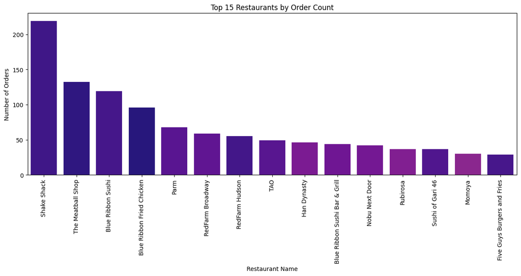

```python
# Analyze top 15 restaurants by order count
plt.figure(figsize=(15, 5))
sns.countplot(data=df, x='restaurant_name', order=df['restaurant_name'].value_counts().head(15).index, palette = 'plasma', hue='restaurant_name', legend=False)
plt.xticks(rotation=90)
plt.title('Top 15 Restaurants by Order Count')
plt.xlabel('Restaurant Name')
plt.ylabel('Number of Orders')
plt.show()
```

Observation -

- The dataset includes orders from a total of 178 unique restaurants.
- A significant number of these restaurants (50 out of 178) have only received one order in the dataset. This suggests that a considerable portion of the restaurants on the platform may not be generating repeat business through the app, at least within the timeframe of this data.
- The majority of restaurants (128 out of 178) have received multiple orders, indicating a core group of restaurants that are regularly utilized by customers.
- Out of all the unique restaurants, only one restaurant, "The Meatball Shop," offers more than one unique cuisine type according to this data. This suggests that most restaurants on the platform specialize in a single cuisine type.

#### Cuisine type

```python
# Check unique cuisine type
print(df['cuisine_type'].unique())

# Check nunique value of 'cuisine_type'
print(df['cuisine_type'].nunique())

# Find the value counts
print(df['cuisine_type'].value_counts())
```

```
['Korean' 'Japanese' 'Mexican' 'American' 'Indian' 'Italian'
 'Mediterranean' 'Chinese' 'Middle Eastern' 'Thai' 'Southern' 'French'
 'Spanish' 'Vietnamese']
14
American          584
Japanese          470
Italian           298
Chinese           215
Mexican            77
Indian             73
Middle Eastern     49
Mediterranean      46
Thai               19
French             18
Southern           17
Korean             13
Spanish            12
Vietnamese          7
Name: cuisine_type, dtype: int64
```

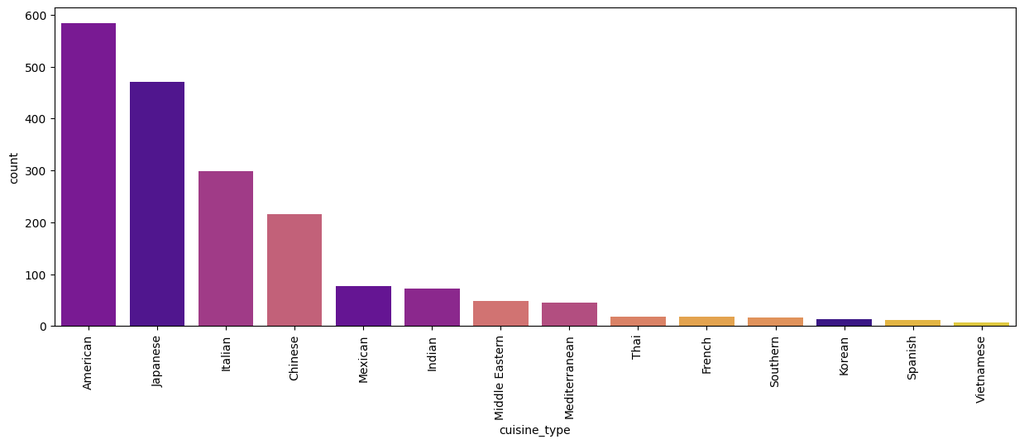

```python
## Create a countplot for cuisine type.
plt.figure(figsize = (15,5))
ax = sns.countplot(data = df, x = 'cuisine_type', order = df['cuisine_type'].value_counts(ascending=False).index, palette = 'plasma', hue='cuisine_type', legend=False)
plt.xticks(rotation = 90)
plt.show()
```

```python
# Calculate the percentage of orders by cuisine type
print(df['cuisine_type'].value_counts(normalize=True) * 100)
```

```
American          30.769231
Japanese          24.762908
Italian           15.700738
Chinese           11.327713
Mexican            4.056902
Indian             3.846154
Middle Eastern     2.581665
Mediterranean      2.423604
Thai               1.001054
French             0.948367
Southern           0.895680
Korean             0.684932
Spanish            0.632244
Vietnamese         0.368809
Name: cuisine_type, dtype: float64
```

Observation -

- Popular cuisines in this dataset are American, Japanese, Italian and Chinese.
- They comprise almost 80% of the orders

#### Cost of the order

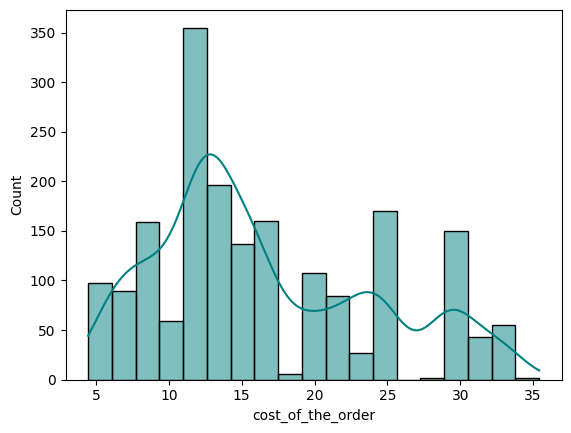

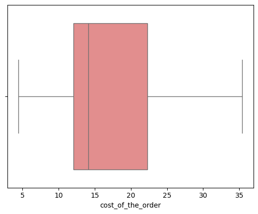

```
count    1898.000000
mean       16.498851
std         7.483812
min         4.470000
25%        12.080000
50%        14.140000
75%        22.297500
max        35.410000
Name: cost_of_the_order, dtype: float64
```

```python
sns.histplot(data=df,x='cost_of_the_order', kde = True, color = 'teal') ## Histogram for the cost of order
plt.show()
sns.boxplot(data=df,x='cost_of_the_order', color = 'lightcoral') ## Boxplot for the cost of order
plt.show()
print(df['cost_of_the_order'].describe().T)
```

Observation -

- The average cost of an order is approximately 16.50 dollars.
- The median cost of an order is 14.14 dollars, which is close to the mean, suggesting the distribution of order costs is relatively symmetrical, although the slightly higher mean suggests a small right skew.
- The interquartile range (IQR) from the 25th percentile (12.08 dollars) to the 75th percentile (22.30 dollars) covers a range of about 10.22 dollars, indicating the middle 50% of order costs fall within this range.
- The minimum order cost is 4.47 dollars and the maximum is 35.41 dollars.
- Specifically, the 50th percentile (median) is 14.14 dollars, meaning that 50% of the orders cost 14.14 dollars or less.

#### Day of the week

```python
# # Check the unique values
df['day_of_the_week'].unique() ## Complete the code to check unique values for the 'day_of_the_week' column
```

```
array(['Weekend', 'Weekday'], dtype=object)
```

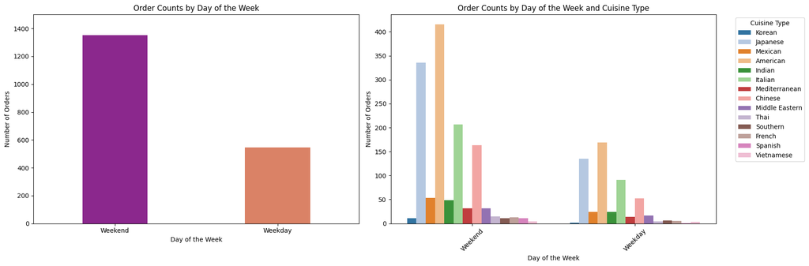

```python
## Create countplots for day of the week side-by-side
plt.figure(figsize = (18, 6)) # Adjust figure size to accommodate two plots

# Subplot 1: Day of the week countplot
plt.subplot(1, 2, 1) # 1 row, 2 columns, first plot
sns.countplot(data = df, x = 'day_of_the_week', palette = 'plasma', hue='day_of_the_week', legend=False, width = 0.4)
plt.title('Order Counts by Day of the Week') # Add a title for clarity
plt.xlabel('Day of the Week')
plt.ylabel('Number of Orders')
plt.ylim(0, 1500) # Set a consistent y-limit for comparison if needed

# Subplot 2: Day of the week countplot with cuisine type hue
plt.subplot(1, 2, 2) # 1 row, 2 columns, second plot
sns.countplot(data = df, x = 'day_of_the_week', hue = 'cuisine_type', palette = 'tab20') # Add hue
plt.xticks(rotation = 45) # Rotate x-axis labels if they overlap due to hue
plt.title('Order Counts by Day of the Week and Cuisine Type') # Add a title for clarity
plt.xlabel('Day of the Week')
plt.ylabel('Number of Orders')
plt.legend(title='Cuisine Type', bbox_to_anchor=(1.05, 1), loc='upper left') # Move legend outside the plot
plt.tight_layout() # Adjust layout to prevent overlapping

plt.show()
```

```python
# Get the value counts for 'day_of_the_week'
day_counts = df['day_of_the_week'].value_counts()

# Calculate the total number of orders
total_orders = df.shape[0]

# Calculate the percentage for each day
percentage_orders = (day_counts / total_orders) * 100

print("Percentage of orders by day of the week:")
print(percentage_orders)
```

```
Percentage of orders by day of the week:
Weekend    71.18019
Weekday    28.81981
Name: day_of_the_week, dtype: float64
```

Observation -

- Orders are higher on the weekends compared to weekdays.
- The volume of weekend orders is 71% of the total, and weekday orders are 28%.

#### Rating

```python
# Check the unique values and their counts for the 'rating' column
print("Unique values in 'rating' column:", df['rating'].unique())

# Get the counts of each rating value
rating_counts = df['rating'].value_counts()
print("\nValue counts for 'rating' column:")
print(rating_counts)

# Get the percentage of each rating value
rating_percentages = df['rating'].value_counts(normalize=True) * 100
print("\nPercentage distribution for 'rating' column:")
print(rating_percentages)
```

```
Unique values in 'rating' column: ['Not given' '5' '3' '4']

Value counts for 'rating' column:
Not given    736
5            588
4            386
3            188
Name: rating, dtype: int64

Percentage distribution for 'rating' column:
Not given    38.777661
5            30.979979
4            20.337197
3             9.905163
Name: rating, dtype: float64
```

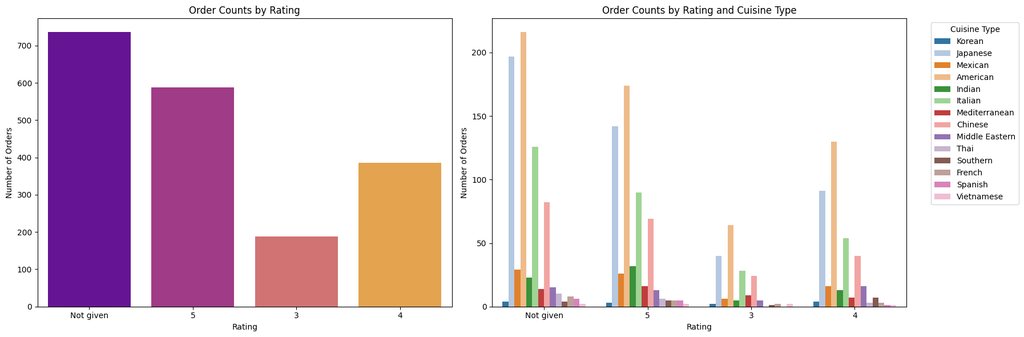

```python
## Create countplots for rating side-by-side
plt.figure(figsize = (18, 6)) # Adjust figure size

# Subplot 1: Rating countplot
plt.subplot(1, 2, 1) # 1 row, 2 columns, first plot
sns.countplot(data = df, x = 'rating', palette = 'plasma', hue='rating', legend=False)
plt.title('Order Counts by Rating')
plt.xlabel('Rating')
plt.ylabel('Number of Orders')

# Subplot 2: Rating countplot with cuisine type hue
plt.subplot(1, 2, 2) # 1 row, 2 columns, second plot
sns.countplot(data = df, x = 'rating', hue = 'cuisine_type', palette = 'tab20') # Using 'tab20' for more distinct colors
plt.title('Order Counts by Rating and Cuisine Type')
plt.xlabel('Rating')
plt.ylabel('Number of Orders')
plt.legend(title='Cuisine Type', bbox_to_anchor=(1.05, 1), loc='upper left') # Move legend outside
plt.tight_layout() # Adjust layout

plt.show()
```

```python
# Check the number of orders with 'Not given' rating for each restaurant
df_not_given = df[df['rating'] == 'Not given']['cuisine_type'].value_counts()
df_not_given[df_not_given > 1]
```

|  | cuisine_type |
| --- | --- |
| American | 216 |
| Japanese | 197 |
| Italian | 126 |
| Chinese | 82 |
| Mexican | 29 |
| Indian | 23 |
| Middle Eastern | 15 |
| Mediterranean | 14 |
| Thai | 10 |
| French | 8 |
| Spanish | 6 |
| Korean | 4 |
| Southern | 4 |
| Vietnamese | 2 |

**dtype:** int64

```
           Weekday  Weekend
Not given      207      529
5              168      420
4              109      277
3               63      125
             Weekday    Weekend
Not given  37.842779  39.156181
5          30.712980  31.088083
4          19.926874  20.503331
3          11.517367   9.252406
```

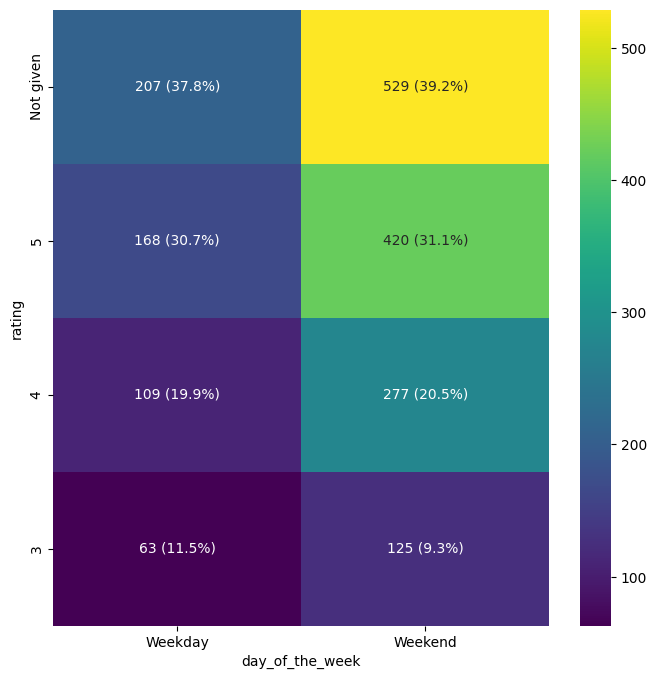

```python
# Relationship between 'day_of_the_week' and 'rating'

from matplotlib import pyplot as plt
import seaborn as sns
import pandas as pd
import numpy as np # Import numpy for handling potential NaN values

plt.subplots(figsize=(8, 8))
df_2dhist = pd.DataFrame({
    x_label: grp['rating'].value_counts()
    for x_label, grp in df.groupby('day_of_the_week')
})
print(df_2dhist)

# Calculate the percentage of each rating per day
df_percentage = df_2dhist.apply(lambda x: x / x.sum() * 100, axis=0)
print(df_percentage)

# Create annotation text with both count and percentage
# Use a helper function to format the text
def format_annotation(count, percentage):
    if np.isnan(count): # Handle cases where there are no orders for a rating/day combination
        return ""
    return f"{int(count)} ({percentage:.1f}%)"

# Create a new DataFrame with formatted strings for annotation
annotation_data = df_2dhist.copy().astype(float) # Ensure the copy is float to handle NaN
for col in annotation_data.columns:
    for index in annotation_data.index:
        count = df_2dhist.loc[index, col]
        percentage = df_percentage.loc[index, col]
        annotation_data.loc[index, col] = format_annotation(count, percentage)


sns.heatmap(df_2dhist, cmap='viridis', annot=annotation_data, fmt='s') # Use the formatted strings for annotation
plt.xlabel('day_of_the_week')
_ = plt.ylabel('rating')
plt.show()
```

Observations -

- 736 out of 1898 orders are not rated which comprises of 38.7%
- A substantial percentage of orders remain unrated on both weekdays (37.84%) and weekends (39.16%) suggesting rating is not heavily influenced by the day of the week.
- The combined percentage of 4 and 5-star ratings is high on both weekdays (30.71% + 19.93% = 50.64%) and weekends (31.09% + 20.50% = 51.59%) indicating more posotive rating being given and is not influenced by whether it is weekday or weekend.
- The 3 star rating is relatively low on both weekends and weekdays.

#### Food Preparation time

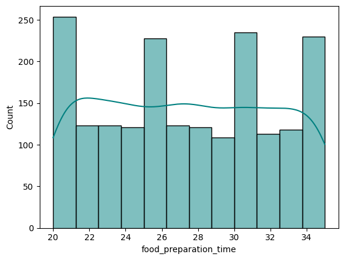

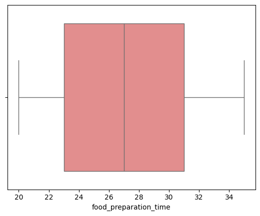

```
count    1898.000000
mean       27.371970
std         4.632481
min        20.000000
25%        23.000000
50%        27.000000
75%        31.000000
max        35.000000
Name: food_preparation_time, dtype: float64
```

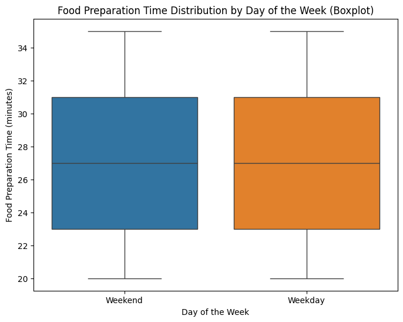

```python
## Plot the histogram and boxplot for the food_preparation_time
sns.histplot(data=df,x='food_preparation_time', kde = True, color = 'teal')
plt.show()

sns.boxplot(data=df,x='food_preparation_time', color = 'lightcoral')
plt.show()
print(df['food_preparation_time'].describe().T)

## Plot boxplots for food_preparation_time separated by day of the week
plt.figure(figsize=(8, 6)) # Adjust figure size if needed
sns.boxplot(data=df, x='day_of_the_week', y='food_preparation_time', hue = 'day_of_the_week', palette='tab10') # Use day of the week on x-axis and delivery time on y-axis
plt.title('Food Preparation Time Distribution by Day of the Week (Boxplot)')
plt.xlabel('Day of the Week')
plt.ylabel('Food Preparation Time (minutes)')
plt.show()
```

Observation -

- Food preparation time shows consistency, ranging from 20 to 35 minutes with a mean of ~27 minutes.
- This consistency aids operational predictability for delivery estimation.

#### Delivery time

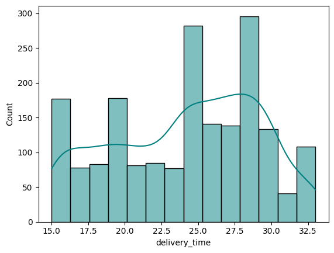

```
count    1898.000000
mean       24.161749
std         4.972637
min        15.000000
25%        20.000000
50%        25.000000
75%        28.000000
max        33.000000
Name: delivery_time, dtype: float64
```

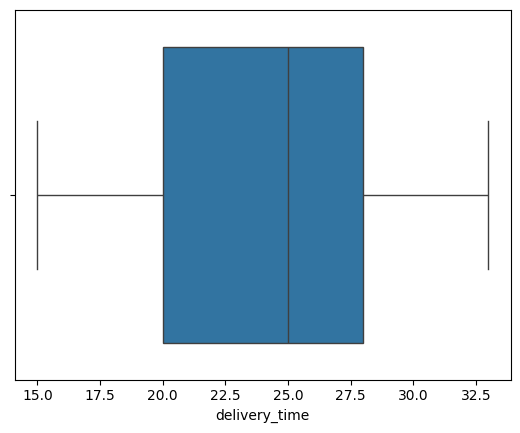

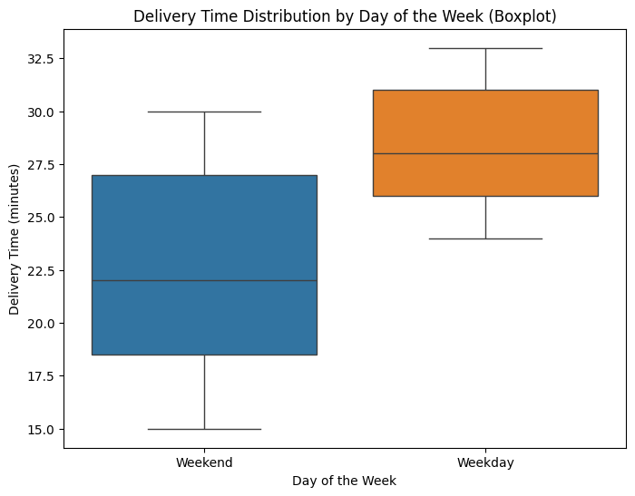

```python
## Plot the histogram and box for the delivery time
sns.histplot(data=df,x='delivery_time', kde = True, color = 'teal')
plt.show()

print(df['delivery_time'].describe().T)

sns.boxplot(data=df,x='delivery_time')
plt.show()

## Plot boxplots for delivery time separated by day of the week
plt.figure(figsize=(8, 6)) # Adjust figure size if needed
sns.boxplot(data=df, x='day_of_the_week', y='delivery_time', hue = 'day_of_the_week', palette='tab10') # Use day of the week on x-axis and delivery time on y-axis
plt.title('Delivery Time Distribution by Day of the Week (Boxplot)')
plt.xlabel('Day of the Week')
plt.ylabel('Delivery Time (minutes)')
plt.show()
```

```python
print(df[df['day_of_the_week'] == 'Weekday']['delivery_time'].describe().T)
print(df[df['day_of_the_week'] == 'Weekend']['delivery_time'].describe().T)
```

```
count    547.000000
mean      28.340037
std        2.891428
min       24.000000
25%       26.000000
50%       28.000000
75%       31.000000
max       33.000000
Name: delivery_time, dtype: float64
count    1351.000000
mean       22.470022
std         4.628938
min        15.000000
25%        18.500000
50%        22.000000
75%        27.000000
max        30.000000
Name: delivery_time, dtype: float64
```

Observation -

- The mean delivery time is approximately 24.16 minutes, with a range from 15 to 33 minutes.
- Delivery times appear to be longer on weekdays compared to weekends.

### **Question 7:** Which are the top 5 restaurants in terms of the number of orders received? [1 mark]

```python
# Get top 5 restaurants with highest number of orders
df['restaurant_name'].value_counts().head(5)
```

|  | restaurant_name |
| --- | --- |
| Shake Shack | 219 |
| The Meatball Shop | 132 |
| Blue Ribbon Sushi | 119 |
| Blue Ribbon Fried Chicken | 96 |
| Parm | 68 |

**dtype:** int64

### **Answer 7:** The top 5 restaurants in terms of the number of orders received are:

| Rank | Restaurant Name | Number of Orders |
| --- | --- | --- |
| 1 | Shake Shack | 219 |
| 2 | The Meatball Shop | 132 |
| 3 | Blue Ribbon Sushi | 119 |
| 4 | Blue Ribbon Fried Chicken | 96 |
| 5 | Parm | 68 |

### **Question 8:** Which is the most popular cuisine on weekends? [1 mark]

```python
# Get most popular cuisine on weekends
df_weekend = df[df['day_of_the_week'] == 'Weekend']
df_weekend['cuisine_type'].value_counts()
```

|  | cuisine_type |
| --- | --- |
| American | 415 |
| Japanese | 335 |
| Italian | 207 |
| Chinese | 163 |
| Mexican | 53 |
| Indian | 49 |
| Mediterranean | 32 |
| Middle Eastern | 32 |
| Thai | 15 |
| French | 13 |
| Korean | 11 |
| Southern | 11 |
| Spanish | 11 |
| Vietnamese | 4 |

**dtype:** int64

### **Answer 8:** The most popular cuisine on weekends is American.

### **Question 9:** What percentage of the orders cost more than 20 dollars? [2 marks]

```python
# Get orders that cost above 20 dollars
df_greater_than_20 = df[df['cost_of_the_order']>20]

# Calculate the number of total orders where the cost is above 20 dollars
print('The number of total orders that cost above 20 dollars is:', df_greater_than_20.shape[0])

# Calculate percentage of such orders in the dataset
percentage = (df_greater_than_20.shape[0] / df.shape[0]) * 100

print("Percentage of orders above 20 dollars:", round(percentage, 2), '%')
```

```
The number of total orders that cost above 20 dollars is: 555
Percentage of orders above 20 dollars: 29.24 %
```

### **Answer 9:** 29.24% of the orders cost more than 20 dollars.

### **Question 10:** What is the mean order delivery time? [1 mark]

```python
# Get the mean delivery time
mean_del_time = df['delivery_time'].mean()

print('The mean delivery time for this dataset is', round(mean_del_time, 2), 'minutes')
```

```
The mean delivery time for this dataset is 24.16 minutes
```

### **Answer 10:** The mean order delivery time is 24.16 minutes.

### **Question 11:** The company has decided to give 20% discount vouchers to the top 5 most frequent customers. Find the IDs of these customers and the number of orders they placed. [1 mark]

```python
# Get the counts of  each customer_id
df['customer_id'].value_counts().head(5)
```

|  | customer_id |
| --- | --- |
| 52832 | 13 |
| 47440 | 10 |
| 83287 | 9 |
| 250494 | 8 |
| 259341 | 7 |

**dtype:** int64

### Answer 11: Top 5 most frequent customers are:

| Rank | Customer ID | Number of Orders |
| --- | --- | --- |
| 1 | 52832 | 13 |
| 2 | 47440 | 10 |
| 3 | 83287 | 9 |
| 4 | 250494 | 8 |
| 5 | 259341 | 7 |

### **Question 12:** Perform a multivariate analysis to explore relationships between the important variables in the dataset. (It is a good idea to explore relations between numerical variables as well as relations between numerical and categorical variables) [10 marks]

#### Cuisine vs Cost of the order

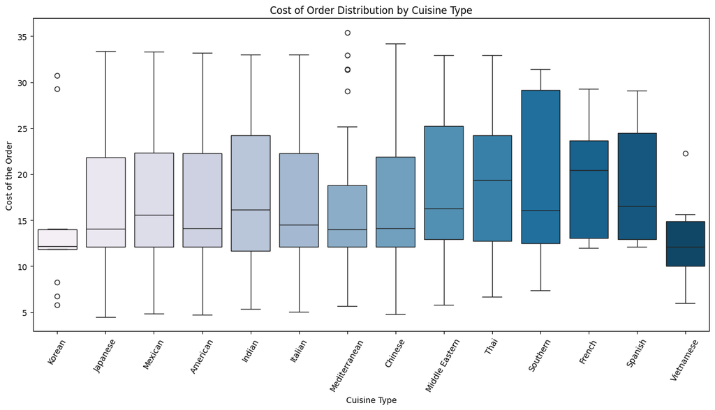

```python
# Relationship between cost of the order and cuisine type
plt.figure(figsize=(15,7))
sns.boxplot(x = "cuisine_type", y = "cost_of_the_order", data = df, palette = 'PuBu', hue = "cuisine_type")
plt.xticks(rotation = 60)
plt.title('Cost of Order Distribution by Cuisine Type')
plt.xlabel('Cuisine Type')
plt.ylabel('Cost of the Order')
plt.show()
```

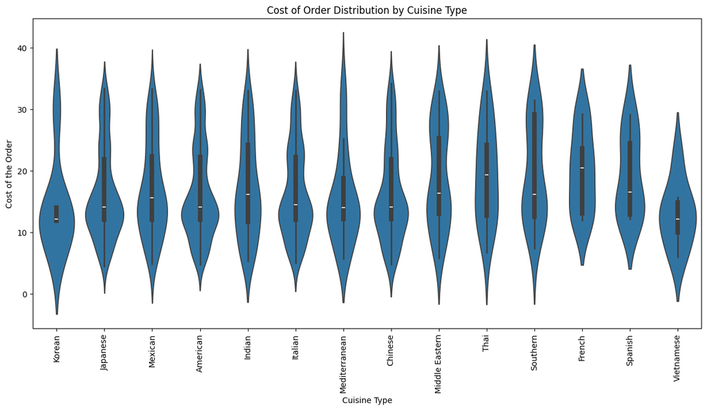

```python
plt.figure(figsize=(15, 7)) # Adjust figure size as needed
sns.violinplot(x='cuisine_type', y='cost_of_the_order', data=df)
plt.xticks(rotation=90) # Rotate labels if they overlap
plt.title('Cost of Order Distribution by Cuisine Type')
plt.xlabel('Cuisine Type')
plt.ylabel('Cost of the Order')
plt.show()
```

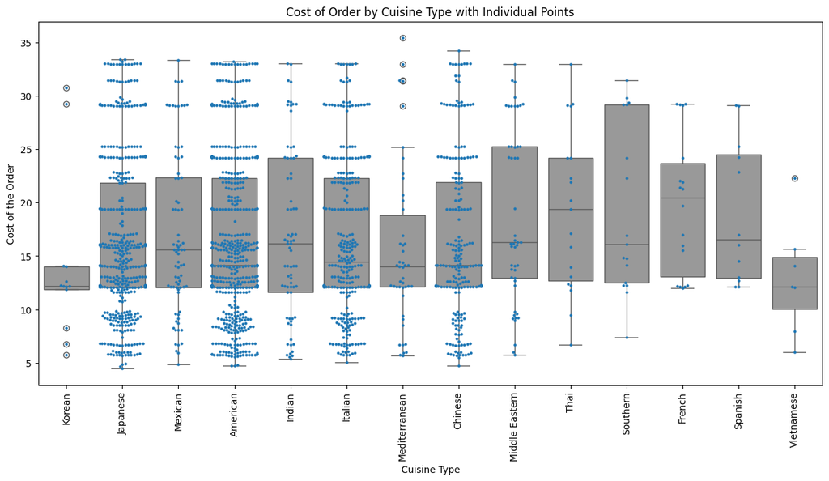

```python
plt.figure(figsize=(15, 7)) # Adjust figure size as needed
sns.boxplot(x='cuisine_type', y='cost_of_the_order', data=df, color=".6") # Add a muted boxplot for context
sns.swarmplot(x='cuisine_type', y='cost_of_the_order', data=df, size=3) # Add the swarmplot
plt.xticks(rotation=90) # Rotate labels if they overlap
plt.title('Cost of Order by Cuisine Type with Individual Points')
plt.xlabel('Cuisine Type')
plt.ylabel('Cost of the Order')
plt.show()
```

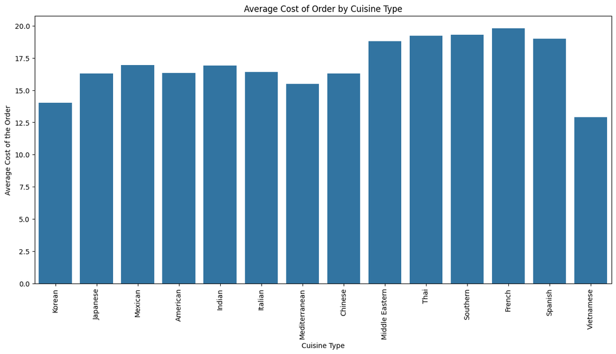

```python
plt.figure(figsize=(15, 7)) # Adjust figure size as needed
sns.barplot(x='cuisine_type', y='cost_of_the_order', data=df, errorbar=None) # ci=None removes confidence intervals for simplicity
plt.xticks(rotation=90) # Rotate labels if they overlap
plt.title('Average Cost of Order by Cuisine Type')
plt.xlabel('Cuisine Type')
plt.ylabel('Average Cost of the Order')
plt.show()
```

Observation -

- The average cost of orders for the most popular cuisines (American, Japanese, Italian, and Chinese) are relatively similar, as indicated by the similar central tendencies (mean/median) in the boxplots.
- The wide distribution of order costs within these top cuisines, as shown by the range from the lower to upper whiskers in the boxplots, suggests diverse spending habits even within popular cuisine types.

#### Cuisine vs Food Preparation time

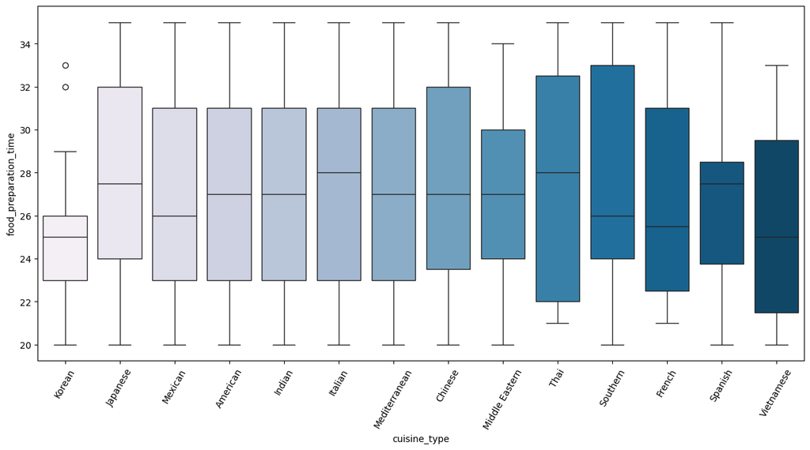

```python
# Relationship between food preparation time and cuisine type
plt.figure(figsize=(15,7))
sns.boxplot(x = 'cuisine_type', y = 'food_preparation_time', data = df, palette = 'PuBu', hue = 'cuisine_type')
plt.xticks(rotation = 60)
plt.show()
```

#### Day of the Week vs Delivery time

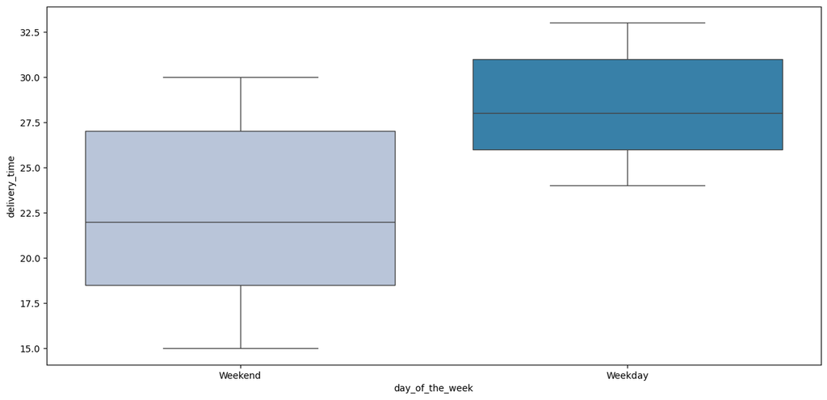

```python
# Relationship between day of the week and delivery time
plt.figure(figsize=(15,7))
sns.boxplot(x = 'day_of_the_week', y = 'delivery_time', data = df, palette = 'PuBu', hue = 'day_of_the_week')
plt.show()
```

#### The revenue generated by the restaurants.

```python
df.groupby(['restaurant_name'])['cost_of_the_order'].sum().sort_values(ascending = False).head(14)
```

| restaurant_name | cost_of_the_order |
| --- | --- |
| Shake Shack | 3579.53 |
| The Meatball Shop | 2145.21 |
| Blue Ribbon Sushi | 1903.95 |
| Blue Ribbon Fried Chicken | 1662.29 |
| Parm | 1112.76 |
| RedFarm Broadway | 965.13 |
| RedFarm Hudson | 921.21 |
| TAO | 834.50 |
| Han Dynasty | 755.29 |
| Blue Ribbon Sushi Bar & Grill | 666.62 |
| Rubirosa | 660.45 |
| Sushi of Gari 46 | 640.87 |
| Nobu Next Door | 623.67 |
| Five Guys Burgers and Fries | 506.47 |

**dtype:** float64

#### Rating vs Delivery time

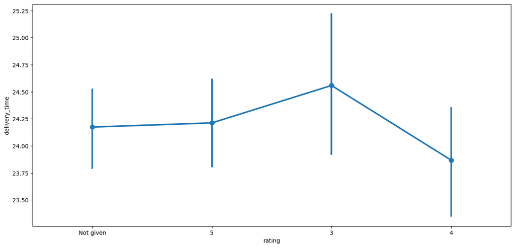

```python
# Relationship between rating and delivery time
plt.figure(figsize=(15, 7))
sns.pointplot(x = 'rating', y = 'delivery_time', data = df)
plt.show()
```

#### Rating vs Food preparation time

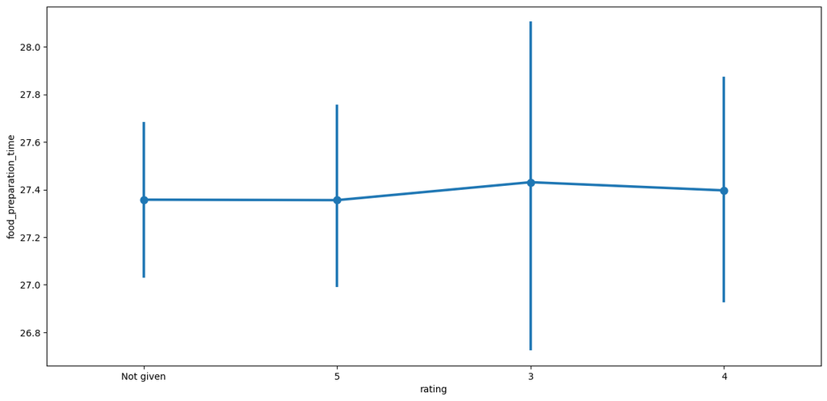

```python
# Relationship between rating and food preparation time
plt.figure(figsize=(15, 7))
sns.pointplot(x = 'rating', y = 'food_preparation_time', data = df)  ## Complete the code to visualize the relationship between rating and food preparation time using pointplot
plt.show()
```

#### Rating vs Cost of the order

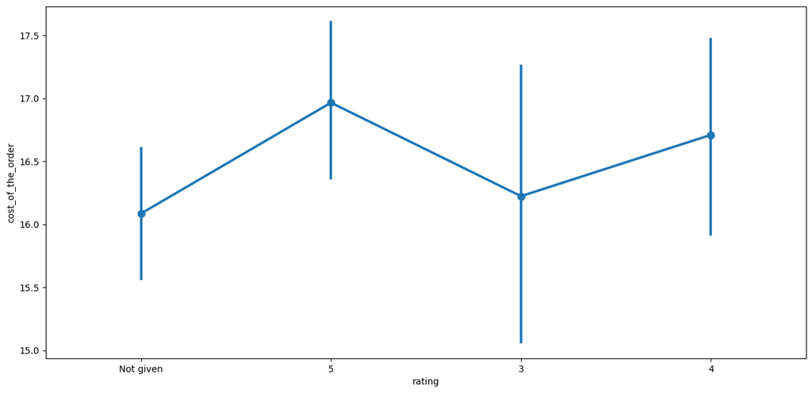

```python
# Relationship between rating and cost of the order
plt.figure(figsize=(15, 7))
sns.pointplot(x = 'rating', y = 'cost_of_the_order', data = df)   ## Complete the code to visualize the relationship between rating and cost of the order using pointplot
plt.show()
```

#### Correlation among variables

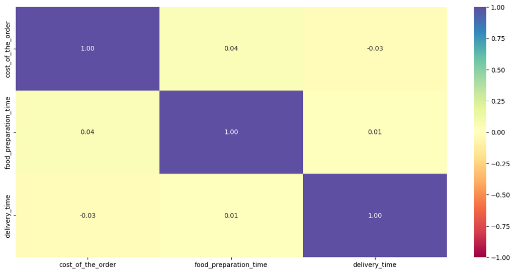

```python
# Plot the heatmap
col_list = ['cost_of_the_order', 'food_preparation_time', 'delivery_time']
plt.figure(figsize=(15, 7))
sns.heatmap(df[col_list].corr(), annot=True,  vmin=-1, vmax=1, fmt=".2f", cmap="Spectral")
plt.show()
```

### **Question 13:** The company wants to provide a promotional offer in the advertisement of the restaurants. The condition to get the offer is that the restaurants must have a rating count of more than 50 and the average rating should be greater than 4. Find the restaurants fulfilling the criteria to get the promotional offer. [3 marks]

```python
# Filter the rated restaurants
df_rated = df[df['rating'] != 'Not given'].copy()

# Convert rating column from object to integer
df_rated['rating'] = df_rated['rating'].astype('int')

# Create a dataframe that contains the restaurant names with their rating counts
df_rating_count = df_rated.groupby(['restaurant_name'])['rating'].count().sort_values(ascending = False).reset_index()
print(df_rating_count.head())
```

```
             restaurant_name  rating
0                Shake Shack     133
1          The Meatball Shop      84
2          Blue Ribbon Sushi      73
3  Blue Ribbon Fried Chicken      64
4           RedFarm Broadway      41
```

```python
pd.set_option('display.width', 300)
```

```python
# Get the restaurant names that have rating count more than 50
rest_names = df_rating_count[df_rating_count['rating'] > 50 ]['restaurant_name']

# Filter to get the data of restaurants that have rating count more than 50
df_mean_4 = df_rated[df_rated['restaurant_name'].isin(rest_names)].copy()

# Group the restaurant names with their ratings and find the mean rating of each restaurant
df_mean_4_rating = df_mean_4.groupby(['restaurant_name'])['rating'].mean().sort_values(ascending = False).reset_index().dropna()

# filter for average rating greater than 4
df_avg_rating_greater_than_4 = df_mean_4_rating[df_mean_4_rating['rating'] > 4].sort_values(by='rating', ascending=False).reset_index(drop=True)

df_avg_rating_greater_than_4
```

|  | restaurant_name | rating |
| --- | --- | --- |
| 0 | The Meatball Shop | 4.511905 |
| 1 | Blue Ribbon Fried Chicken | 4.328125 |
| 2 | Shake Shack | 4.278195 |
| 3 | Blue Ribbon Sushi | 4.219178 |

### **Answer 13:** Restaurants in the below list qualify for the promotion.

| restaurant_name | rating |
| --- | --- |
| The Meatball Shop | 4.51 |
| Blue Ribbon Fried Chicken | 4.33 |
| Shake Shack | 4.28 |
| Blue Ribbon Sushi | 4.22 |

### **Question 14:** The company charges the restaurant 25% on the orders having cost greater than 20 dollars and 15% on the orders having cost greater than 5 dollars. Find the net revenue generated by the company across all orders. [3 marks]

```python
#function to determine the revenue
def compute_rev(x):
    if x > 20:
        return x*0.25
    elif x > 5:
        return x*0.15
    else:
        return x*0

df['Revenue'] = df['cost_of_the_order'].apply(compute_rev)
df.head()
```

|  | order_id | customer_id | restaurant_name | cuisine_type | cost_of_the_order | day_of_the_week | rating | food_preparation_time | delivery_time | Revenue |
| --- | --- | --- | --- | --- | --- | --- | --- | --- | --- | --- |
| 0 | 1477147 | 337525 | Hangawi | Korean | 30.75 | Weekend | Not given | 25 | 20 | 7.6875 |
| 1 | 1477685 | 358141 | Blue Ribbon Sushi Izakaya | Japanese | 12.08 | Weekend | Not given | 25 | 23 | 1.8120 |
| 2 | 1477070 | 66393 | Cafe Habana | Mexican | 12.23 | Weekday | 5 | 23 | 28 | 1.8345 |
| 3 | 1477334 | 106968 | Blue Ribbon Fried Chicken | American | 29.20 | Weekend | 3 | 25 | 15 | 7.3000 |
| 4 | 1478249 | 76942 | Dirty Bird to Go | American | 11.59 | Weekday | 4 | 25 | 24 | 1.7385 |

```python
# get the total revenue and print it
total_rev = df['Revenue'].sum() ## Write the appropriate function to get the total revenue
print('The net revenue is around', round(total_rev, 2), 'dollars')
```

```
The net revenue is around 6166.3 dollars
```

### **Answer 14:** The net revenue generated is around 6166.3 dollars

### **Question 15:** The company wants to analyze the total time required to deliver the food. What percentage of orders take more than 60 minutes to get delivered from the time the order is placed? (The food has to be prepared and then delivered.)[2 marks]

```python
# Calculate total delivery time and add a new column to the dataframe df to store the total delivery time
df['total_time'] = df['food_preparation_time'] + df['delivery_time']


## Write the code below to find the percentage of orders that have more than 60 minutes of total delivery time
df_more_than_60_mins = df[df['total_time'] > 60]['total_time'].count()
percentage_df_more_than_60_mins = (df_more_than_60_mins / df.shape[0]) * 100
print('The percentage of orders that take more than 60 minutes to get delivered is', round(percentage_df_more_than_60_mins, 2), '%')
```

```
The percentage of orders that take more than 60 minutes to get delivered is 10.54 %
```

### **Answer 15:** The percentage of orders that take more than 60 minutes to get delivered is 10.54 %

### **Question 16:** The company wants to analyze the delivery time of the orders on weekdays and weekends. How does the mean delivery time vary during weekdays and weekends? [2 marks]

```python
# Get the mean delivery time on weekdays and print it
print('The mean delivery time on weekdays is around',
      round(df[df['day_of_the_week'] == 'Weekday']['delivery_time'].mean()),
     'minutes')


## Write the code below to get the mean delivery time on weekends and print it
print('The mean delivery time on weekends is around',
      round(df[df['day_of_the_week'] == 'Weekend']['delivery_time'].mean()),
     'minutes')
```

```
The mean delivery time on weekdays is around 28 minutes
The mean delivery time on weekends is around 22 minutes
```

### **Answer 16:** The mean delivery time on weekdays is approximately 28 minutes, while the mean delivery time on weekends is approximately 22 minutes. This indicates that, on average, orders take longer to be delivered during the week compared to the weekend.

### Conclusion and Recommendations

### **Question 17:** What are your conclusions from the analysis? What recommendations would you like to share to help improve the business? (You can use cuisine type and feedback ratings to drive your business recommendations.) [6 marks]

### Conclusions:

- American, Japanese, Italian, and Chinese cuisines dominate orders, collectively representing almost 80% of total volume and highlighting key areas for targeted marketing and restaurant acquisition strategies.
- 128 out of 178 restaurants (72%) receive repeat orders.
- Orders are significantly higher on weekends, accounting for 71% of total order volume, indicating a strong weekend demand and potential for targeted weekend promotions and resource allocation.
- 50% of orders are under 15 dollar and 75% are under 23 dollar suggests that a significant portion of customer base tends to place orders within a lower to moderate price range. This indicates that many customers are likely budget-conscious.
- Consistent food preparation times (ranging 20-35 mins, mean ~27 mins) support reliable delivery estimates.

### Recommendations:

- To drive significant business growth, FoodHub must prioritize strategies aimed at converting the 65.33% of customers who currently order only once into repeat patrons, potentially by addressing factors contributing to unrated orders and enhancing the initial customer experience.
- 50 out of 178 restaurants (28%) have received only a single order.This highlights an opportunity to address factors hindering their recurring business through the platform.
- A large proportion of orders are not rated, but when ratings are given, they are predominantly positive (4 or 5 stars). This highlights the opportunity to encourage more customers to rate their orders, potentially through implementing customer incentive programs.
- Delivery times appear to be longer on weekdays compared to weekends, which may contribute to lower order volumes during the week and presents an opportunity for FoodHub to improve delivery efficiency.